# Data_Visualization_Of_Accident_Rate_Without_Seatbelts

Tugas Portofolio Geeked

## Data Visualization of Accident Rate Without Seatbelts

Kemudahan kita dalam berpergian yaitu dengan menggunakan tranportasi, bisa tranportasi umum maupun transportasi pribadi. Selain memudahkan untuk berpergian, kendaraan pribadi juga dapat menghemat pengeluaran. Namun, sering kali pengemudi kendaraan pribadi tidak bijak dalam penggunaannya, seperti mengemudi tanpa memakai sabuk pengaman. Oleh karena itu, saya berminat dengan data tingkat kecelakaan tanpa menggunakan sabuk pengaman untuk dijadikan pengetahuan saya dan semua orang, dengan melihat visualisasi data dari jumlah kecelakaan tanpa menggunakan sabuk pengaman.

1. Unnamed:0 = nomor
2. Year = tahun
3. Month = bulan
4. DriversKilled = jumlah pengemudi yang meninggal
5. drivers = jumlah pengemudi
6. front = kecelakaan bagian depan
7. rear = kecelakaan bagian belakang
8. kms = kilometer
9. PetrolPrice = Harga Bensin
10. VanKilled = Jumlah Pengemudi minibus/van yang meninggal
11. law = hukum

# Membaca Data

```python
import pandas as pd
ar = pd.read_csv("seatbelts.csv")
```

Menampilkan data tingkat kecelakaan tanpa menggunakan sabuk pengaman

```python
ar
```

|  | Unnamed: 0 | Year | Month | DriversKilled | drivers | front | rear | kms | PetrolPrice | VanKilled | law |
| --- | --- | --- | --- | --- | --- | --- | --- | --- | --- | --- | --- |
| 0 | 1 | 1969 | Jan | 107 | 1687 | 867 | 269 | 9059 | 0.102972 | 12 | 0 |
| 1 | 2 | 1969 | Feb | 97 | 1508 | 825 | 265 | 7685 | 0.102363 | 6 | 0 |
| 2 | 3 | 1969 | Mar | 102 | 1507 | 806 | 319 | 9963 | 0.102062 | 12 | 0 |
| 3 | 4 | 1969 | Apr | 87 | 1385 | 814 | 407 | 10955 | 0.100873 | 8 | 0 |
| 4 | 5 | 1969 | May | 119 | 1632 | 991 | 454 | 11823 | 0.101020 | 10 | 0 |
| ... | ... | ... | ... | ... | ... | ... | ... | ... | ... | ... | ... |
| 187 | 188 | 1984 | Aug | 96 | 1284 | 644 | 521 | 21626 | 0.114797 | 5 | 1 |
| 188 | 189 | 1984 | Sep | 122 | 1444 | 643 | 429 | 20195 | 0.114093 | 7 | 1 |
| 189 | 190 | 1984 | Oct | 120 | 1575 | 641 | 408 | 19928 | 0.116466 | 7 | 1 |
| 190 | 191 | 1984 | Nov | 137 | 1737 | 711 | 490 | 18564 | 0.116026 | 4 | 1 |
| 191 | 192 | 1984 | Dec | 154 | 1763 | 721 | 491 | 18149 | 0.116067 | 7 | 1 |

192 rows × 11 columns

Melihat informasi tentang dataframe kecelakaan tanpa menggunakan sabuk pengaman

```python
ar.info()
```

```
<class 'pandas.core.frame.DataFrame'>
RangeIndex: 192 entries, 0 to 191
Data columns (total 11 columns):
 #   Column         Non-Null Count  Dtype
---  ------         --------------  -----
 0   Unnamed: 0     192 non-null    int64
 1   Year           192 non-null    int64
 2   Month          192 non-null    object
 3   DriversKilled  192 non-null    int64
 4   drivers        192 non-null    int64
 5   front          192 non-null    int64
 6   rear           192 non-null    int64
 7   kms            192 non-null    int64
 8   PetrolPrice    192 non-null    float64
 9   VanKilled      192 non-null    int64
 10  law            192 non-null    int64
dtypes: float64(1), int64(9), object(1)
memory usage: 16.6+ KB
```

Memeriksa apakah terdapat nilai null pada dataframe kecelakaan tanpa menggunakan sabuk pengaman

```python
ar.isnull().values.any()
```

```
False
```

Memeriksa apakah ada data duplikat pada dataframe kecelakaan tanpa menggunakan sabuk pengaman

```python
ar.duplicated()
```

```
0      False
1      False
2      False
3      False
4      False
       ...
187    False
188    False
189    False
190    False
191    False
Length: 192, dtype: bool
```

Mengubah format dari object menjadi str

```python
ar['Month'] = ar['Month'].astype(str)
```

# Mencari Hubungan Antara Tahun dan Jumlah Pengemudi

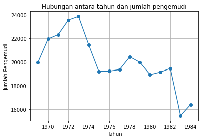

```python
import matplotlib.pyplot as plt
Year = ar.groupby(['Year']).sum()
plt.plot(Year['drivers'],marker = 'o')
plt.grid()
plt.title("Hubungan antara tahun dan jumlah pengemudi")
plt.xlabel("Tahun")
plt.ylabel("Jumlah Pengemudi")
```

#### Dihasilkan bahwa jumlah pengemudi meninggi dari tahun 1971 - 1973

# Hubungan Antara Tahun dan Jumlah Pengemudi Yang Meninggal

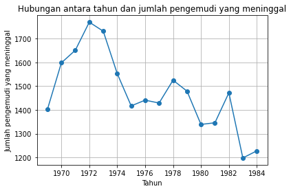

```python
import matplotlib.pyplot as plt
Year = ar.groupby(['Year']).sum()
plt.plot(Year['DriversKilled'],marker = 'o')
plt.grid()
plt.title("Hubungan antara tahun dan jumlah pengemudi yang meninggal")
plt.xlabel("Tahun")
plt.ylabel("Jumlah pengemudi yang meninggal")
```

#### Dihasilkan bahwa tahun 1972 paling banyak jumlah pengemudi yang meninggal

# Mencari Hubungan Antara Tahun dan Jumlah Pengemudi Minibus/Van yang meninggal

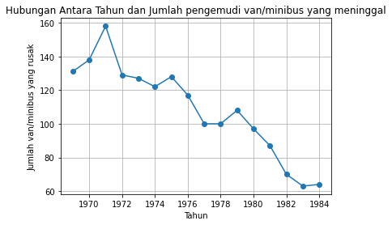

```python
import matplotlib.pyplot as plt
Year = ar.groupby(['Year']).sum()
plt.plot(Year['VanKilled'],marker = 'o')
plt.grid()
plt.title("Hubungan Antara Tahun dan Jumlah pengemudi van/minibus yang meninggal")
plt.xlabel("Tahun")
plt.ylabel("Jumlah van/minibus yang rusak")
```

#### Dihasilkan bahwa paling banyak pada tahun 1971 pengemudi van/minibus yang meninggal dunia.

# Mencari Hubungan Antara Tahun dan Kecelakaan Bagian Depan

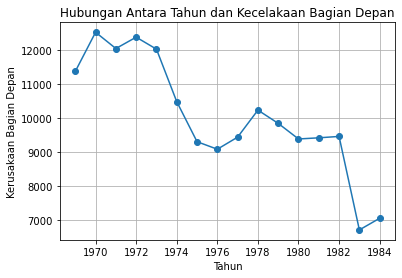

```python
import matplotlib.pyplot as plt
Year = ar.groupby(['Year']).sum()
plt.plot(Year['front'],marker = 'o')
plt.grid()
plt.title("Hubungan Antara Tahun dan Kecelakaan Bagian Depan")
plt.xlabel("Tahun")
plt.ylabel("Kerusakaan Bagian Depan")
```

#### Dihasilkan bahwa paling banyak kecelakaan bagian depan terjadi pada tahun 1970

# Mencari Hubungan Antara Tahun dan Kecelakaan Bagian Belakang

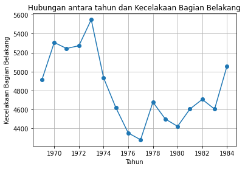

```python
import matplotlib.pyplot as plt
Year = ar.groupby(['Year']).sum()
plt.plot(Year['rear'],marker = 'o')
plt.grid()
plt.title("Hubungan antara tahun dan Kecelakaan Bagian Belakang")
plt.xlabel("Tahun")
plt.ylabel("Kecelakaan Bagian Belakang")
```

#### Dihasilkan bahwa paling banyak kecelakaan bagian belakang terdapat pada tahun 1973

### Sehingga dapat disimpulkan bahwa :

Jumlah pengemudi meninggi pada tahun 1971-1973. Pada tahun 1972 paling banyak jumlah pengemudi yang meninggal, tahun 1971 paling banyak jumlah pengemudi van/minibus yang meninggal dunia, dan kecelakaan bagian depan terjadi paling banyak pada tahun 1970, dan kecelakaan bagian belakang terjadi paling banyak pada tahun 1973. Untuk mendapatkan tingkat penurunan kecelakaan yang terjadi yaitu para pengemudi harus selalu menggunakan sabuk pengaman dalam mengendarai kendaraan pribadi atau minibus/van.